# 01 The tidy text format

H. David Shea

29 Jul 2021

## The `unnest_tokens` function

```r
text <- c(
    "Because I could not stop for Death -",
    "He kindly stopped for me -",
    "The Carriage held but just Ourselves -",
    "and Immortality"
)

kable(text)
```

| x |
| --- |
| Because I could not stop for Death - |
| He kindly stopped for me - |
| The Carriage held but just Ourselves - |
| and Immortality |

```r
text_df <- tibble(line = 1:4, text = text)

kable(text_df)
```

| line | text |
| --- | --- |
| 1 | Because I could not stop for Death - |
| 2 | He kindly stopped for me - |
| 3 | The Carriage held but just Ourselves - |
| 4 | and Immortality |

```r
text_df %>%
    unnest_tokens(word, text) %>%
    kable()
```

| line | word |
| --- | --- |
| 1 | because |
| 1 | i |
| 1 | could |
| 1 | not |
| 1 | stop |
| 1 | for |
| 1 | death |
| 2 | he |
| 2 | kindly |
| 2 | stopped |
| 2 | for |
| 2 | me |
| 3 | the |
| 3 | carriage |
| 3 | held |
| 3 | but |
| 3 | just |
| 3 | ourselves |
| 4 | and |
| 4 | immortality |

```r
text_df %>%
    unnest_tokens(word, text, to_lower = FALSE) %>%
    kable()
```

| line | word |
| --- | --- |
| 1 | Because |
| 1 | I |
| 1 | could |
| 1 | not |
| 1 | stop |
| 1 | for |
| 1 | Death |
| 2 | He |
| 2 | kindly |
| 2 | stopped |
| 2 | for |
| 2 | me |
| 3 | The |
| 3 | Carriage |
| 3 | held |
| 3 | but |
| 3 | just |
| 3 | Ourselves |
| 4 | and |
| 4 | Immortality |

## Tidying the works of Jane Austen

Get the text from all Jane Austen books, add fields for line number and chapter number. The line number is obtained by a simple `row_number()` call. The chapter number relies on a `cumsum` of each line that starts with the word ‘chapter’ followed by a space and then a number or any of the (smaller - i.e., no ‘m’ - not a lot of 1000 chapter books) Roman numeral letters - neat trick.

NOTE: The `austen_books()` data are in text only format - exactly what we want - so no pre-processing is required.

```r
original_books <- austen_books() %>%
    group_by(book) %>%
    mutate(linenumber = row_number(),
           chapter = cumsum(str_detect(
               text,
               regex("^chapter [\\divxlc]",
                     ignore_case = TRUE)
           ))) %>%
    ungroup()

kable(original_books[1:10, ])
```

| text | book | linenumber | chapter |
| --- | --- | --- | --- |
| SENSE AND SENSIBILITY | Sense & Sensibility | 1 | 0 |
|  | Sense & Sensibility | 2 | 0 |
| by Jane Austen | Sense & Sensibility | 3 | 0 |
|  | Sense & Sensibility | 4 | 0 |
| (1811) | Sense & Sensibility | 5 | 0 |
|  | Sense & Sensibility | 6 | 0 |
|  | Sense & Sensibility | 7 | 0 |
|  | Sense & Sensibility | 8 | 0 |
|  | Sense & Sensibility | 9 | 0 |
| CHAPTER 1 | Sense & Sensibility | 10 | 1 |

```r
tidy_books <- original_books %>%
    unnest_tokens(word, text)

kable(tidy_books[1:10, ])
```

| book | linenumber | chapter | word |
| --- | --- | --- | --- |
| Sense & Sensibility | 1 | 0 | sense |
| Sense & Sensibility | 1 | 0 | and |
| Sense & Sensibility | 1 | 0 | sensibility |
| Sense & Sensibility | 3 | 0 | by |
| Sense & Sensibility | 3 | 0 | jane |
| Sense & Sensibility | 3 | 0 | austen |
| Sense & Sensibility | 5 | 0 | 1811 |
| Sense & Sensibility | 10 | 1 | chapter |
| Sense & Sensibility | 10 | 1 | 1 |
| Sense & Sensibility | 13 | 1 | the |

**Stop words** are words that are not usually useful for analyses. These are the typically high frequency common words like ‘the’, ‘of’, ‘to’, etc. The package `tidytext` contains a dataset `stop_words` containing several lexicons’ versions of stop words.

```r
data(stop_words)

tidy_books <- tidy_books %>%
    anti_join(stop_words, by = "word")

tidy_books %>%
    count(word, sort = TRUE) %>%
    slice_max(n, n = 10) %>%
    kable()
```

| word | n |
| --- | --- |
| miss | 1855 |
| time | 1337 |
| fanny | 862 |
| dear | 822 |
| lady | 817 |
| sir | 806 |
| day | 797 |
| emma | 787 |
| sister | 727 |
| house | 699 |

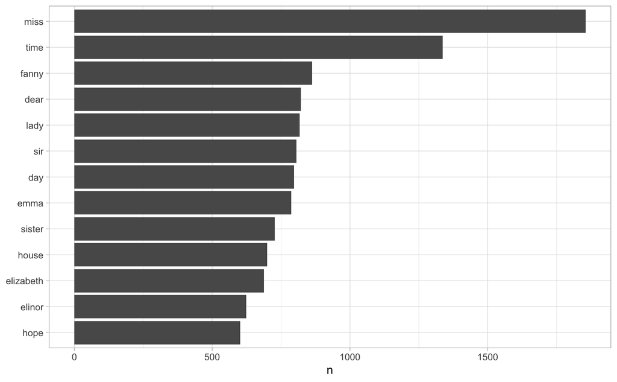

```r
tidy_books %>%
    count(word, sort = TRUE) %>%
    filter(n > 600) %>%
    mutate(word = reorder(word, n)) %>%
    ggplot(aes(n, word)) +
    geom_col() +
    labs(y = NULL) +
    theme_light()
```

## The `gutenbergr` package

[*Project Gutenberg*](https://www.gutenberg.org) is a library of over 60,000 free eBooks. The `gutenbergr` package provides access to these books. Here, we pull the data for some H.G. Wells books: *The Time Machine* (ID = 35), *The War of the Worlds* (ID = 36), *The Invisible Man* (ID = 5230), and *The Island of Doctor Moreau* (ID = 159). Then we do the same for works from the Bronte Sisters: *Jane Eyre* (ID = 1260), *Wuthering Heights* (ID = 768), *The Tenant of Wildfell Hall* (ID = 969), *Villette* (ID = 9182), and *Agnes Grey* (ID = 767).

```r
hgwells <- gutenberg_download(c(35, 36, 5230, 159))

tidy_hgwells <- hgwells %>%
    unnest_tokens(word, text) %>%
    anti_join(stop_words, by = "word")

tidy_hgwells %>%
    count(word, sort = TRUE) %>%
    slice_max(n, n = 10) %>%
    kable()
```

| word | n |
| --- | --- |
| time | 461 |
| people | 302 |
| door | 260 |
| heard | 249 |
| black | 232 |
| stood | 229 |
| white | 224 |
| hand | 218 |
| kemp | 213 |
| eyes | 210 |
| suddenly | 210 |

```r
bronte <- gutenberg_download(c(1260, 768, 969, 9182, 767))

tidy_bronte <- bronte %>%
    unnest_tokens(word, text) %>%
    anti_join(stop_words, by = "word")

tidy_bronte %>%
    count(word, sort = TRUE) %>%
    slice_max(n, n = 10) %>%
    kable()
```

| word | n |
| --- | --- |
| time | 1064 |
| miss | 854 |
| day | 826 |
| hand | 767 |
| eyes | 713 |
| don’t | 666 |
| night | 648 |
| heart | 638 |
| looked | 601 |
| door | 591 |

## Word frequencies

Now we calculate the frequency for each word for the collected work of the set of authors: Jane Austen, the Bronte sisters, and H.G. Wells. This makes good use of `tidverse` operations.

NOTE: The Project Gutenberg books have some examples of emphasized words indicated by underscores. The `str_extract` below, makes sure that only letters and apostrophes are sampled, not the special characters.

```r
frequency <-
    bind_rows(
        mutate(tidy_bronte, author = "Brontë Sisters"),
        mutate(tidy_hgwells, author = "H.G. Wells"),
        mutate(tidy_books, author = "Jane Austen")
    ) %>%
    mutate(word = str_extract(word, "[a-z']+")) %>%
    count(author, word) %>%
    group_by(author) %>%
    mutate(proportion = n / sum(n)) %>%
    select(-n) %>%
    pivot_wider(names_from = author, values_from = proportion) %>%
    pivot_longer(`Brontë Sisters`:`H.G. Wells`,
                 names_to = "author",
                 values_to = "proportion")

kable(frequency[1:10, ])
```

| word | Jane Austen | author | proportion |
| --- | --- | --- | --- |
| a | 9.2e-06 | Brontë Sisters | 0.0000587 |
| a | 9.2e-06 | H.G. Wells | 0.0000148 |
| aback | NA | Brontë Sisters | 0.0000039 |
| aback | NA | H.G. Wells | 0.0000148 |
| abaht | NA | Brontë Sisters | 0.0000039 |
| abaht | NA | H.G. Wells | NA |
| abandon | NA | Brontë Sisters | 0.0000313 |
| abandon | NA | H.G. Wells | 0.0000148 |
| abandoned | 4.6e-06 | Brontë Sisters | 0.0000900 |
| abandoned | 4.6e-06 | H.G. Wells | 0.0001778 |

And this can be used to make a frequency scatter plot to show words used at similar frequencies by the authors - words closer to the abline are similar in frequency.

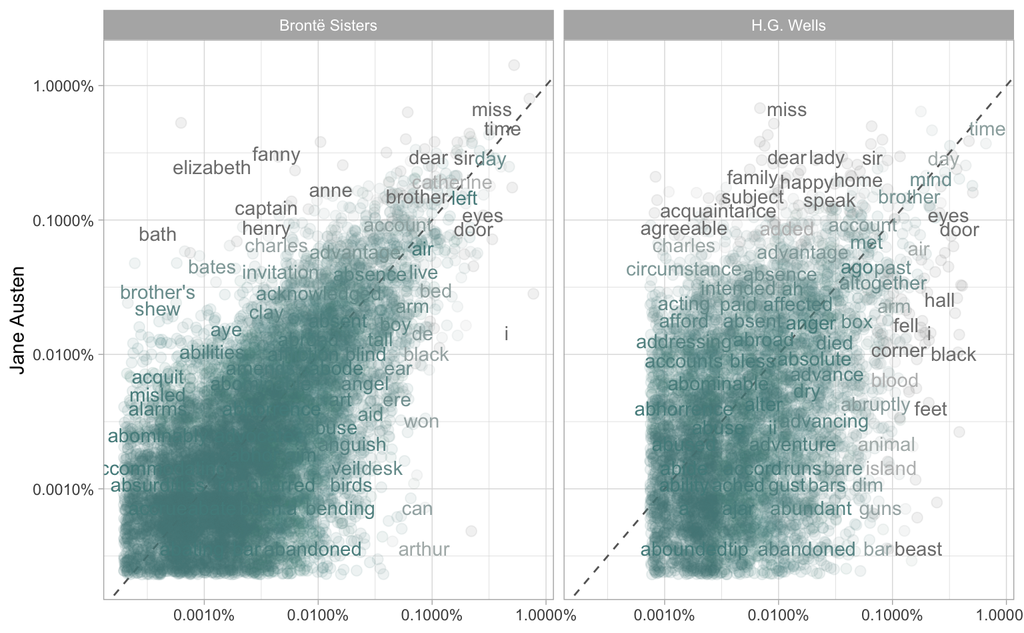

```r
ggplot(frequency, aes(
    x = proportion,
    y = `Jane Austen`,
    color = abs(`Jane Austen` - proportion)
)) +
    geom_abline(color = "gray40", lty = 2) +
    geom_jitter(
        alpha = 0.1,
        size = 2.5,
        width = 0.3,
        height = 0.3,
        na.rm = TRUE
    ) +
    geom_text(
        aes(label = word),
        check_overlap = TRUE,
        vjust = 1.5,
        na.rm = TRUE
    ) +
    scale_x_log10(labels = percent_format()) +
    scale_y_log10(labels = percent_format()) +
    scale_color_gradient(limits = c(0, 0.001),
                         low = "darkslategray4",
                         high = "gray75") +
    facet_wrap( ~ author, ncol = 2) +
    labs(y = "Jane Austen", x = NULL) +
    theme_light() +
    theme(legend.position = "none")
```

Note the difference in shape between the two plots. The Austen-Bronte plots shows more data points, points that are generally closer to the abline and more lower frequency words in common versus the Austen-Wells plot. This indicates that Jane Austen and the Bronte sisters used more similar words than Jane Austen and H.G. Wells did.

This can be shown in correlation tests as well.

```r
cor.test(data = frequency[frequency$author == "Brontë Sisters", ],
         ~ proportion + `Jane Austen`)
```

```
#>
#>  Pearson's product-moment correlation
#>
#> data:  proportion and Jane Austen
#> t = 111.09, df = 10345, p-value < 2.2e-16
#> alternative hypothesis: true correlation is not equal to 0
#> 95 percent confidence interval:
#>  0.7286568 0.7462330
#> sample estimates:
#>       cor
#> 0.7375698
```

```r
cor.test(data = frequency[frequency$author == "H.G. Wells", ],
         ~ proportion + `Jane Austen`)
```

```
#>
#>  Pearson's product-moment correlation
#>
#> data:  proportion and Jane Austen
#> t = 36.083, df = 6046, p-value < 2.2e-16
#> alternative hypothesis: true correlation is not equal to 0
#> 95 percent confidence interval:
#>  0.3999815 0.4414612
#> sample estimates:
#>       cor
#> 0.4209414
```